# Reporting with tidylearn

## Overview

Two families turn a fitted model into something publishable. `plot()` and the `tl_plot_*()` functions return ggplot2 objects, with the exceptions listed under Interactive Reporting with plotly; `tl_table()` and the `tl_table_*()` functions return `gt` tables. Both dispatch on model type, so the same call covers a forest and a lasso fit, and both hand back an object you can keep editing rather than printed output you cannot.

```r
library(tidylearn)
library(dplyr)
library(ggplot2)
library(gt)
```

## Plots

`plot()` picks the visualisation from the model type, and `type` narrows it further where a model supports more than one view.

### Regression

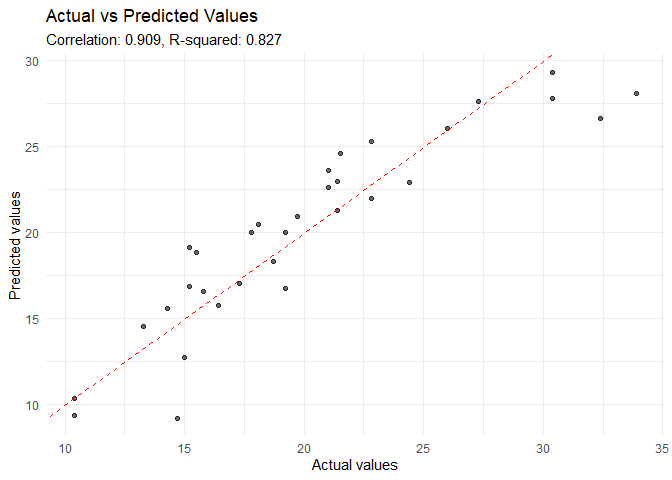

```r
model_reg <- tl_model(mtcars, mpg ~ wt + hp, method = "linear")

# Actual vs predicted — one call
plot(model_reg, type = "actual_predicted")
```

### Classification

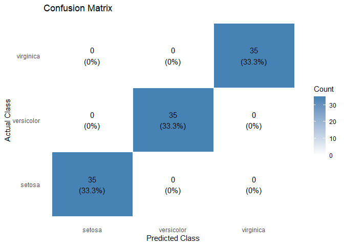

```r
split <- tl_split(iris, prop = 0.7, stratify = "Species", seed = 42)
model_clf <- tl_model(split$train, Species ~ ., method = "forest")

plot(model_clf, type = "confusion")
```

### PCA

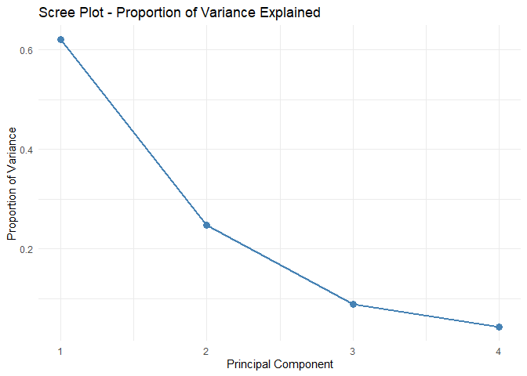

```r
pca <- tidy_pca(USArrests, scale = TRUE)

tidy_pca_screeplot(pca)
```

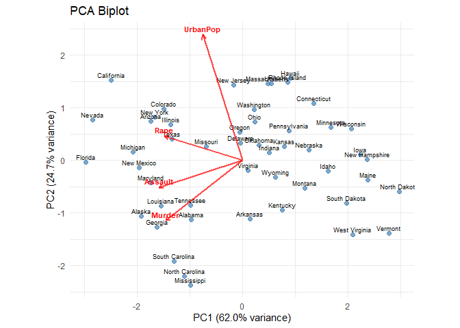

```r
tidy_pca_biplot(pca, label_obs = TRUE)
```

### Regularisation

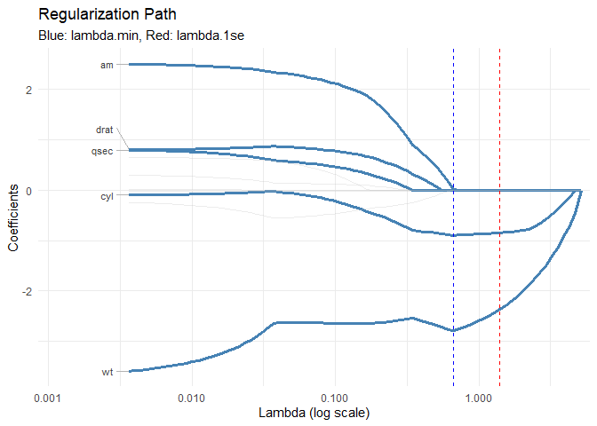

```r
model_lasso <- tl_model(mtcars, mpg ~ ., method = "lasso")

tl_plot_regularization_path(model_lasso)
```

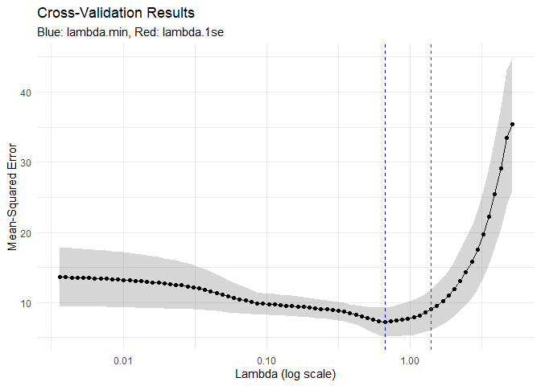

```r
tl_plot_regularization_cv(model_lasso)
```

## Tables

`tl_table()` mirrors the plot interface, dispatching on model type and an optional `type`:

```r
tl_table(model)                       # auto-selects the best table type
tl_table(model, type = "coefficients") # specific type
```

### Evaluation Metrics

```r
tl_table_metrics(model_reg)
```

Model Evaluation Metrics

| Metric | Value |
| --- | --- |
| Rmse | 2.4689 |
| Mae | 1.9015 |
| Rsq | 0.8268 |

tidylearn | linear (regression) | mpg ~ wt + hp | n = 32

### Coefficients

For linear and logistic models, the table includes standard errors, test statistics, and p-values, with significant terms highlighted:

```r
tl_table_coefficients(model_reg)
```

Linear Model Coefficients

| Term | Estimate | Std. Error | t value | p |  |
| --- | --- | --- | --- | --- | --- |
| (Intercept) | 37.2273 | 1.5988 | 23.2847 | 2.57 × 10<sup>−20</sup> | * |
| wt | −3.8778 | 0.6327 | −6.1287 | 1.12 × 10<sup>−6</sup> | * |
| hp | −0.0318 | 0.0090 | −3.5187 | 1.45 × 10<sup>−3</sup> | * |

tidylearn | linear (regression) | mpg ~ wt + hp | n = 32

`conf_int = TRUE` adds a confidence interval, and `level` sets its width:

```r
tl_table_coefficients(model_reg, conf_int = TRUE, level = 0.9)
```

Linear Model Coefficients

Wald 90% intervals

| Term | Estimate | Std. Error | Lower 90% | Upper 90% | t value | p |  |
| --- | --- | --- | --- | --- | --- | --- | --- |
| (Intercept) | 37.2273 | 1.5988 | 34.5107 | 39.9438 | 23.2847 | 2.57 × 10<sup>−20</sup> | * |
| wt | −3.8778 | 0.6327 | −4.9529 | −2.8027 | −6.1287 | 1.12 × 10<sup>−6</sup> | * |
| hp | −0.0318 | 0.0090 | −0.0471 | −0.0164 | −3.5187 | 1.45 × 10<sup>−3</sup> | * |

tidylearn | linear (regression) | mpg ~ wt + hp | n = 32

These are Wald intervals, built from the standard errors in the column beside them, so the interval and the p-value in a row always agree about whether zero is excluded. For a logistic model, `exponentiate = TRUE` reports odds ratios instead of log odds.

For regularised models, coefficients are sorted by magnitude and zero coefficients are greyed out. There is no interval to add — glmnet reports no standard errors, and `conf_int = TRUE` is an error here rather than a column of `NA`:

```r
tl_table_coefficients(model_lasso)
```

Lasso Coefficients

lambda = 1.399 (1se)

| Term | Coefficient | \|Coefficient\| |
| --- | --- | --- |
| (Intercept) | 33.9405 | 33.9405 |
| wt | −2.3659 | 2.3659 |
| cyl | −0.8430 | 0.8430 |
| hp | −0.0070 | 0.0070 |
| disp | 0.0000 | 0.0000 |
| drat | 0.0000 | 0.0000 |
| qsec | 0.0000 | 0.0000 |
| vs | 0.0000 | 0.0000 |
| am | 0.0000 | 0.0000 |
| gear | 0.0000 | 0.0000 |
| carb | 0.0000 | 0.0000 |

tidylearn | lasso (regression) | mpg ~ . | n = 32

The numbers behind these tables come from `tl_coefficients()`, which takes the same arguments, returns a tibble, and does not need `gt` installed:

```r
tl_coefficients(model_reg, conf_int = TRUE)
```

```
#> # A tibble: 3 × 7
#>   term        estimate std_error conf_low conf_high statistic  p_value
#>   <chr>          <dbl>     <dbl>    <dbl>     <dbl>     <dbl>    <dbl>
#> 1 (Intercept)  37.2      1.60     34.0      40.5        23.3  2.57e-20
#> 2 wt           -3.88     0.633    -5.17     -2.58       -6.13 1.12e- 6
#> 3 hp           -0.0318   0.00903  -0.0502   -0.0133     -3.52 1.45e- 3
```

### Confusion Matrix

A formatted confusion matrix with correct predictions highlighted on the diagonal:

```r
tl_table_confusion(model_clf, new_data = split$test)
```

Confusion Matrix

| Actual | Predicted setosa | Predicted versicolor | Predicted virginica |
| --- | --- | --- | --- |
| setosa | 15 | 0 | 0 |
| versicolor | 0 | 15 | 0 |
| virginica | 0 | 2 | 13 |

tidylearn | forest (classification) | Species ~ . | n = 45

### Feature Importance

A ranked importance table with a colour gradient:

```r
tl_table_importance(model_clf)
```

Feature Importance

Top 4 features

| Feature | Importance |
| --- | --- |
| Petal.Length | 100.00 |
| Petal.Width | 90.41 |
| Sepal.Length | 29.86 |
| Sepal.Width | 13.11 |

tidylearn | forest (classification) | Species ~ . | n = 105

### PCA Variance Explained

Cumulative variance is coloured green to highlight how many components are needed:

```r
pca_model <- tl_model(USArrests, method = "pca")
tl_table_variance(pca_model)
```

PCA Variance Explained

| Component | Std. Dev. | Variance | Proportion | Cumulative |
| --- | --- | --- | --- | --- |
| PC1 | 1.5749 | 2.4802 | 62.0% | 62.0% |
| PC2 | 0.9949 | 0.9898 | 24.7% | 86.8% |
| PC3 | 0.5971 | 0.3566 | 8.9% | 95.7% |
| PC4 | 0.4164 | 0.1734 | 4.3% | 100.0% |

tidylearn | pca | n = 50

### PCA Loadings

A diverging red–blue colour scale highlights strong positive and negative loadings:

```r
tl_table_loadings(pca_model)
```

PCA Loadings

| Variable | PC1 | PC2 | PC3 | PC4 |
| --- | --- | --- | --- | --- |
| Murder | −0.536 | −0.418 | 0.341 | 0.649 |
| Assault | −0.583 | −0.188 | 0.268 | −0.743 |
| UrbanPop | −0.278 | 0.873 | 0.378 | 0.134 |
| Rape | −0.543 | 0.167 | −0.818 | 0.089 |

tidylearn | pca | n = 50

### Cluster Summary

Cluster sizes and mean feature values:

```r
km <- tl_model(iris[, 1:4], method = "kmeans", k = 3)
tl_table_clusters(km)
```

Cluster Summary

kmeans | 3 clusters

| Cluster | Size | Sepal.Length | Sepal.Width | Petal.Length | Petal.Width |
| --- | --- | --- | --- | --- | --- |
| 1 | 38 | 6.85 | 3.07 | 5.74 | 2.07 |
| 2 | 50 | 5.01 | 3.43 | 1.46 | 0.25 |
| 3 | 62 | 5.90 | 2.75 | 4.39 | 1.43 |

tidylearn | kmeans | n = 150

### Model Comparison

Compare multiple models side-by-side:

```r
m1 <- tl_model(split$train, Species ~ ., method = "svm")
m2 <- tl_model(split$train, Species ~ ., method = "forest")
m3 <- tl_model(split$train, Species ~ ., method = "tree")

tl_table_comparison(
  m1, m2, m3,
  new_data = split$test,
  names = c("SVM", "Random Forest", "Decision Tree")
)
```

Model Comparison

3 models compared

| Metric | SVM | Random Forest | Decision Tree |
| --- | --- | --- | --- |
| Accuracy | 0.9111 | 0.9556 | 0.8889 |

tidylearn | n = 45

## Interactive Reporting with plotly

Most plot functions return a ggplot2 object, and `ggplotly()` takes any of those without special handling:

```r
library(plotly)

ggplotly(plot(model_reg, type = "actual_predicted"))
ggplotly(tidy_pca_biplot(pca, label_obs = TRUE))
ggplotly(tl_plot_regularization_path(model_lasso))
```

These do not return a single ggplot2 object:

- `plot_dendrogram()`, which `plot()` uses for an hclust model, `tl_plot_tree()` and `tl_plot_nn_architecture()` draw with base graphics.
- `tl_plot_xgboost_tree()` returns a DiagrammeR widget, `tl_plot_deep_architecture()` draws the keras model diagram, and `visualize_rules(method = "paracoord")` draws with grid.
- `tl_diagnostic_dashboard()` and `plot_cluster_comparison()` return an arranged grid of panels. `plot(model, type = "diagnostics")` and `create_cluster_dashboard()` return a list of ggplot2 objects, which `ggplotly()` takes one at a time.
- `plot()` on a `tl_explore()` result draws its plot and returns the exploration result, and `tl_dashboard()` returns a Shiny app.

## Putting It Together

Fit, score, look, drill in — the four calls that make up most reporting sections:

```r
# Fit
model <- tl_model(split$train, Species ~ ., method = "forest")

# Evaluate
tl_table_metrics(model, new_data = split$test)
```

Model Evaluation Metrics

| Metric | Value |
| --- | --- |
| Accuracy | 0.9333 |

tidylearn | forest (classification) | Species ~ . | n = 45

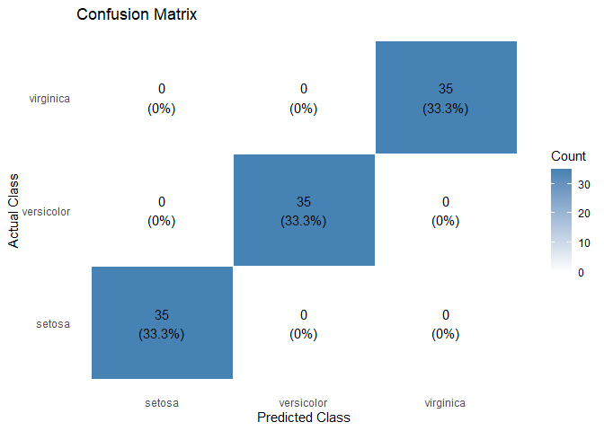

```r
# Visualise
plot(model, type = "confusion")
```

```r
# Drill into feature importance
tl_table_importance(model, top_n = 4)
```

Feature Importance

Top 4 features

| Feature | Importance |
| --- | --- |
| Petal.Length | 100.00 |
| Petal.Width | 88.90 |
| Sepal.Length | 27.46 |
| Sepal.Width | 8.69 |

tidylearn | forest (classification) | Species ~ . | n = 105

Swap `method = "forest"` for `method = "tree"` and the reporting code above works without modification. `tl_table_importance()` covers the tree-based and regularised methods only, so for a method such as `"svm"` or `"nn"`, leave out the last call.